# Risk Factor Analysis

## Outcome Variable

**Outcome Variable:** haz

## Predictor Variables

**Intervention Variable:** nchldlt5

**Adjustment Set:**

- arm
- W_mage
- meducyrs
- feducyrs
- hhwealth_quart
- hfoodsec
- W_mhtcm
- W_mwtkg
- W_mbmi
- W_nrooms
- W_parity
- impfloor
- impsan
- safeh20
- delta_W_mage
- delta_meducyrs
- delta_feducyrs
- delta_hhwealth_quart
- delta_hfoodsec
- delta_W_mhtcm
- delta_W_mwtkg
- delta_W_mbmi
- delta_W_nrooms
- delta_W_parity
- delta_impfloor
- delta_impsan
- delta_safeh20

## Stratifying Variables

The analysis was stratified on these variable(s):

- agecat
- studyid
- country

## Data Summary

| agecat | studyid | country | nchldlt5 | n_cell | n | outcome_variable |
| --- | --- | --- | --- | --- | --- | --- |
| Birth | IRC | INDIA | 1 | 84 | 388 | haz |
| Birth | IRC | INDIA | 2+ | 304 | 388 | haz |
| Birth | JiVitA-3 | BANGLADESH | 1 | 13986 | 22431 | haz |
| Birth | JiVitA-3 | BANGLADESH | 2+ | 8445 | 22431 | haz |
| Birth | NIH-Crypto | BANGLADESH | 1 | 522 | 732 | haz |
| Birth | NIH-Crypto | BANGLADESH | 2+ | 210 | 732 | haz |
| Birth | PROVIDE | BANGLADESH | 1 | 391 | 539 | haz |
| Birth | PROVIDE | BANGLADESH | 2+ | 148 | 539 | haz |
| 6 months | IRC | INDIA | 1 | 89 | 407 | haz |
| 6 months | IRC | INDIA | 2+ | 318 | 407 | haz |
| 6 months | JiVitA-3 | BANGLADESH | 1 | 10887 | 16800 | haz |
| 6 months | JiVitA-3 | BANGLADESH | 2+ | 5913 | 16800 | haz |
| 6 months | LCNI-5 | MALAWI | 1 | 390 | 811 | haz |
| 6 months | LCNI-5 | MALAWI | 2+ | 421 | 811 | haz |
| 6 months | NIH-Crypto | BANGLADESH | 1 | 507 | 715 | haz |
| 6 months | NIH-Crypto | BANGLADESH | 2+ | 208 | 715 | haz |
| 6 months | PROVIDE | BANGLADESH | 1 | 438 | 604 | haz |
| 6 months | PROVIDE | BANGLADESH | 2+ | 166 | 604 | haz |
| 6 months | TanzaniaChild2 | TANZANIA, UNITED REPUBLIC OF | 1 | 1391 | 2020 | haz |
| 6 months | TanzaniaChild2 | TANZANIA, UNITED REPUBLIC OF | 2+ | 629 | 2020 | haz |
| 24 months | IRC | INDIA | 1 | 89 | 409 | haz |
| 24 months | IRC | INDIA | 2+ | 320 | 409 | haz |
| 24 months | JiVitA-3 | BANGLADESH | 1 | 5454 | 8622 | haz |
| 24 months | JiVitA-3 | BANGLADESH | 2+ | 3168 | 8622 | haz |
| 24 months | LCNI-5 | MALAWI | 1 | 283 | 571 | haz |
| 24 months | LCNI-5 | MALAWI | 2+ | 288 | 571 | haz |
| 24 months | NIH-Crypto | BANGLADESH | 1 | 357 | 514 | haz |
| 24 months | NIH-Crypto | BANGLADESH | 2+ | 157 | 514 | haz |
| 24 months | PROVIDE | BANGLADESH | 1 | 424 | 578 | haz |
| 24 months | PROVIDE | BANGLADESH | 2+ | 154 | 578 | haz |
| 24 months | TanzaniaChild2 | TANZANIA, UNITED REPUBLIC OF | 1 | 5 | 6 | haz |
| 24 months | TanzaniaChild2 | TANZANIA, UNITED REPUBLIC OF | 2+ | 1 | 6 | haz |

The following strata were considered:

- agecat: 24 months, studyid: IRC, country: INDIA
- agecat: 24 months, studyid: JiVitA-3, country: BANGLADESH
- agecat: 24 months, studyid: LCNI-5, country: MALAWI
- agecat: 24 months, studyid: NIH-Crypto, country: BANGLADESH
- agecat: 24 months, studyid: PROVIDE, country: BANGLADESH
- agecat: 24 months, studyid: TanzaniaChild2, country: TANZANIA, UNITED REPUBLIC OF
- agecat: 6 months, studyid: IRC, country: INDIA
- agecat: 6 months, studyid: JiVitA-3, country: BANGLADESH
- agecat: 6 months, studyid: LCNI-5, country: MALAWI
- agecat: 6 months, studyid: NIH-Crypto, country: BANGLADESH
- agecat: 6 months, studyid: PROVIDE, country: BANGLADESH
- agecat: 6 months, studyid: TanzaniaChild2, country: TANZANIA, UNITED REPUBLIC OF
- agecat: Birth, studyid: IRC, country: INDIA
- agecat: Birth, studyid: JiVitA-3, country: BANGLADESH
- agecat: Birth, studyid: NIH-Crypto, country: BANGLADESH
- agecat: Birth, studyid: PROVIDE, country: BANGLADESH

### Dropped Strata

Some strata were dropped due to rare outcomes:

- agecat: 24 months, studyid: TanzaniaChild2, country: TANZANIA, UNITED REPUBLIC OF

## Methods Detail

We’re interested in the causal parameters $E[Y_a]$ for all values of $a \in \mathcal{A}$. These parameters represent the mean outcome if, possibly contrary to fact, we intervened to set all units to have $A=a$. Under the randomization and positivity assumptions, these are identified by the statistical parameters $\psi_a=E_W[E_{Y|A,W}(Y|A=a,W)]$. In addition, we’re interested in the mean of $Y$, $E[Y]$ under no intervention (the observed mean). We will estimate these parameters by using SuperLearner to fit the relevant likelihood factors – $E_{Y|A,W}(Y|A=a,W)$ and $p(A=a|W)$, and then updating our likelihood fit using a joint TMLE.

For unadjusted analyses ($W=\{\}$), initial likelihoods were estimated using Lrnr_glm to estimate the simple $E(Y|A)$ and Lrnr_mean to estimate $p(A)$. For adjusted analyses, a small library containing Lrnr_glmnet, Lrnr_xgboost, and Lrnr_mean was used.

Having estimated these parameters, we will then use the delta method to estimate relative risks and attributable risks relative to a prespecified baseline level of $A$.

# Results Detail

## Results Plots

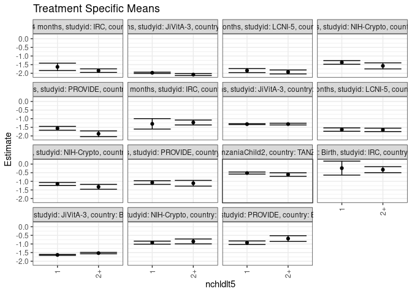

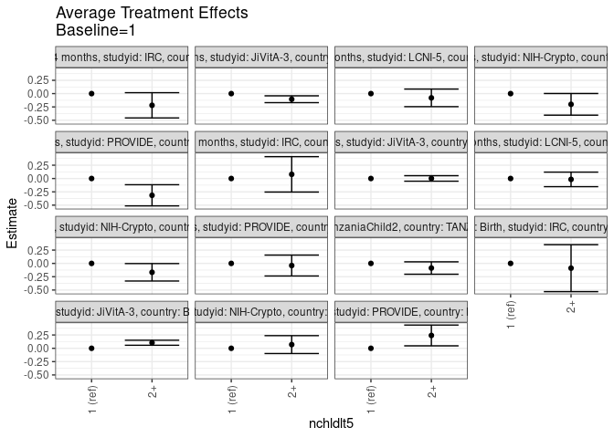

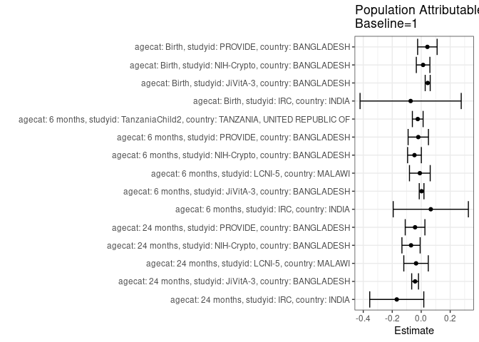

## Results Table

### Parameter: TSM

| agecat | studyid | country | intervention_level | baseline_level | estimate | ci_lower | ci_upper |
| --- | --- | --- | --- | --- | --- | --- | --- |
| Birth | IRC | INDIA | 1 | NA | -0.2350337 | -0.6396521 | 0.1695847 |
| Birth | IRC | INDIA | 2+ | NA | -0.3242614 | -0.4987946 | -0.1497283 |
| Birth | JiVitA-3 | BANGLADESH | 1 | NA | -1.6344739 | -1.6619129 | -1.6070349 |
| Birth | JiVitA-3 | BANGLADESH | 2+ | NA | -1.5301645 | -1.5702299 | -1.4900991 |
| Birth | NIH-Crypto | BANGLADESH | 1 | NA | -0.9225622 | -1.0107218 | -0.8344027 |
| Birth | NIH-Crypto | BANGLADESH | 2+ | NA | -0.8530484 | -0.9956765 | -0.7104203 |
| Birth | PROVIDE | BANGLADESH | 1 | NA | -0.9276054 | -1.0300207 | -0.8251902 |
| Birth | PROVIDE | BANGLADESH | 2+ | NA | -0.6863683 | -0.8521896 | -0.5205471 |
| 6 months | IRC | INDIA | 1 | NA | -1.3004979 | -1.6019261 | -0.9990696 |
| 6 months | IRC | INDIA | 2+ | NA | -1.2223748 | -1.3642615 | -1.0804881 |
| 6 months | JiVitA-3 | BANGLADESH | 1 | NA | -1.3158124 | -1.3443041 | -1.2873207 |
| 6 months | JiVitA-3 | BANGLADESH | 2+ | NA | -1.3145637 | -1.3627985 | -1.2663288 |
| 6 months | LCNI-5 | MALAWI | 1 | NA | -1.6336945 | -1.7320381 | -1.5353510 |
| 6 months | LCNI-5 | MALAWI | 2+ | NA | -1.6503943 | -1.7481226 | -1.5526660 |
| 6 months | NIH-Crypto | BANGLADESH | 1 | NA | -1.1521635 | -1.2383203 | -1.0660067 |
| 6 months | NIH-Crypto | BANGLADESH | 2+ | NA | -1.3193072 | -1.4597397 | -1.1788746 |
| 6 months | PROVIDE | BANGLADESH | 1 | NA | -1.0714574 | -1.1770619 | -0.9658529 |
| 6 months | PROVIDE | BANGLADESH | 2+ | NA | -1.1114532 | -1.2767391 | -0.9461674 |
| 6 months | TanzaniaChild2 | TANZANIA, UNITED REPUBLIC OF | 1 | NA | -0.5202551 | -0.5801923 | -0.4603180 |
| 6 months | TanzaniaChild2 | TANZANIA, UNITED REPUBLIC OF | 2+ | NA | -0.6072183 | -0.7082066 | -0.5062300 |
| 24 months | IRC | INDIA | 1 | NA | -1.6300055 | -1.8431181 | -1.4168929 |
| 24 months | IRC | INDIA | 2+ | NA | -1.8496257 | -1.9535451 | -1.7457064 |
| 24 months | JiVitA-3 | BANGLADESH | 1 | NA | -1.9711882 | -2.0079166 | -1.9344597 |
| 24 months | JiVitA-3 | BANGLADESH | 2+ | NA | -2.0766556 | -2.1337381 | -2.0195731 |
| 24 months | LCNI-5 | MALAWI | 1 | NA | -1.8449894 | -1.9641161 | -1.7258626 |
| 24 months | LCNI-5 | MALAWI | 2+ | NA | -1.9248165 | -2.0389611 | -1.8106719 |
| 24 months | NIH-Crypto | BANGLADESH | 1 | NA | -1.3710289 | -1.4764405 | -1.2656174 |
| 24 months | NIH-Crypto | BANGLADESH | 2+ | NA | -1.5723384 | -1.7474946 | -1.3971822 |
| 24 months | PROVIDE | BANGLADESH | 1 | NA | -1.5600230 | -1.6698971 | -1.4501489 |
| 24 months | PROVIDE | BANGLADESH | 2+ | NA | -1.8756285 | -2.0420876 | -1.7091694 |

### Parameter: E(Y)

| agecat | studyid | country | intervention_level | baseline_level | estimate | ci_lower | ci_upper |
| --- | --- | --- | --- | --- | --- | --- | --- |
| Birth | IRC | INDIA | NA | NA | -0.3080412 | -0.4687931 | -0.1472894 |
| Birth | JiVitA-3 | BANGLADESH | NA | NA | -1.5897031 | -1.6089786 | -1.5704276 |
| Birth | NIH-Crypto | BANGLADESH | NA | NA | -0.9094945 | -0.9809370 | -0.8380521 |
| Birth | PROVIDE | BANGLADESH | NA | NA | -0.8851020 | -0.9601332 | -0.8100709 |
| 6 months | IRC | INDIA | NA | NA | -1.2344062 | -1.3658524 | -1.1029600 |
| 6 months | JiVitA-3 | BANGLADESH | NA | NA | -1.3131375 | -1.3362767 | -1.2899983 |
| 6 months | LCNI-5 | MALAWI | NA | NA | -1.6431566 | -1.7128296 | -1.5734836 |
| 6 months | NIH-Crypto | BANGLADESH | NA | NA | -1.1986783 | -1.2700937 | -1.1272630 |
| 6 months | PROVIDE | BANGLADESH | NA | NA | -1.0916915 | -1.1661176 | -1.0172654 |
| 6 months | TanzaniaChild2 | TANZANIA, UNITED REPUBLIC OF | NA | NA | -0.5442232 | -0.5932373 | -0.4952090 |
| 24 months | IRC | INDIA | NA | NA | -1.7987775 | -1.8923914 | -1.7051636 |
| 24 months | JiVitA-3 | BANGLADESH | NA | NA | -2.0134284 | -2.0411019 | -1.9857549 |
| 24 months | LCNI-5 | MALAWI | NA | NA | -1.8806830 | -1.9625334 | -1.7988326 |
| 24 months | NIH-Crypto | BANGLADESH | NA | NA | -1.4412646 | -1.5249156 | -1.3576135 |
| 24 months | PROVIDE | BANGLADESH | NA | NA | -1.6024221 | -1.6857420 | -1.5191023 |

### Parameter: ATE

| agecat | studyid | country | intervention_level | baseline_level | estimate | ci_lower | ci_upper |
| --- | --- | --- | --- | --- | --- | --- | --- |
| Birth | IRC | INDIA | 1 | 1 | 0.0000000 | 0.0000000 | 0.0000000 |
| Birth | IRC | INDIA | 2+ | 1 | -0.0892277 | -0.5301922 | 0.3517367 |
| Birth | JiVitA-3 | BANGLADESH | 1 | 1 | 0.0000000 | 0.0000000 | 0.0000000 |
| Birth | JiVitA-3 | BANGLADESH | 2+ | 1 | 0.1043094 | 0.0568289 | 0.1517899 |
| Birth | NIH-Crypto | BANGLADESH | 1 | 1 | 0.0000000 | 0.0000000 | 0.0000000 |
| Birth | NIH-Crypto | BANGLADESH | 2+ | 1 | 0.0695138 | -0.0982776 | 0.2373052 |
| Birth | PROVIDE | BANGLADESH | 1 | 1 | 0.0000000 | 0.0000000 | 0.0000000 |
| Birth | PROVIDE | BANGLADESH | 2+ | 1 | 0.2412371 | 0.0463472 | 0.4361270 |
| 6 months | IRC | INDIA | 1 | 1 | 0.0000000 | 0.0000000 | 0.0000000 |
| 6 months | IRC | INDIA | 2+ | 1 | 0.0781231 | -0.2542388 | 0.4104850 |
| 6 months | JiVitA-3 | BANGLADESH | 1 | 1 | 0.0000000 | 0.0000000 | 0.0000000 |
| 6 months | JiVitA-3 | BANGLADESH | 2+ | 1 | 0.0012487 | -0.0502680 | 0.0527654 |
| 6 months | LCNI-5 | MALAWI | 1 | 1 | 0.0000000 | 0.0000000 | 0.0000000 |
| 6 months | LCNI-5 | MALAWI | 2+ | 1 | -0.0166998 | -0.1529751 | 0.1195756 |
| 6 months | NIH-Crypto | BANGLADESH | 1 | 1 | 0.0000000 | 0.0000000 | 0.0000000 |
| 6 months | NIH-Crypto | BANGLADESH | 2+ | 1 | -0.1671437 | -0.3311194 | -0.0031679 |
| 6 months | PROVIDE | BANGLADESH | 1 | 1 | 0.0000000 | 0.0000000 | 0.0000000 |
| 6 months | PROVIDE | BANGLADESH | 2+ | 1 | -0.0399959 | -0.2362934 | 0.1563017 |
| 6 months | TanzaniaChild2 | TANZANIA, UNITED REPUBLIC OF | 1 | 1 | 0.0000000 | 0.0000000 | 0.0000000 |
| 6 months | TanzaniaChild2 | TANZANIA, UNITED REPUBLIC OF | 2+ | 1 | -0.0869632 | -0.2033806 | 0.0294543 |
| 24 months | IRC | INDIA | 1 | 1 | 0.0000000 | 0.0000000 | 0.0000000 |
| 24 months | IRC | INDIA | 2+ | 1 | -0.2196203 | -0.4569339 | 0.0176934 |
| 24 months | JiVitA-3 | BANGLADESH | 1 | 1 | 0.0000000 | 0.0000000 | 0.0000000 |
| 24 months | JiVitA-3 | BANGLADESH | 2+ | 1 | -0.1054675 | -0.1697072 | -0.0412277 |
| 24 months | LCNI-5 | MALAWI | 1 | 1 | 0.0000000 | 0.0000000 | 0.0000000 |
| 24 months | LCNI-5 | MALAWI | 2+ | 1 | -0.0798271 | -0.2449030 | 0.0852489 |
| 24 months | NIH-Crypto | BANGLADESH | 1 | 1 | 0.0000000 | 0.0000000 | 0.0000000 |
| 24 months | NIH-Crypto | BANGLADESH | 2+ | 1 | -0.2013094 | -0.4046965 | 0.0020776 |
| 24 months | PROVIDE | BANGLADESH | 1 | 1 | 0.0000000 | 0.0000000 | 0.0000000 |
| 24 months | PROVIDE | BANGLADESH | 2+ | 1 | -0.3156055 | -0.5142400 | -0.1169710 |

### Parameter: PAR

| agecat | studyid | country | intervention_level | baseline_level | estimate | ci_lower | ci_upper |
| --- | --- | --- | --- | --- | --- | --- | --- |
| Birth | IRC | INDIA | 1 | NA | -0.0730075 | -0.4221309 | 0.2761159 |
| Birth | JiVitA-3 | BANGLADESH | 1 | NA | 0.0447708 | 0.0274998 | 0.0620418 |
| Birth | NIH-Crypto | BANGLADESH | 1 | NA | 0.0130677 | -0.0338068 | 0.0599422 |
| Birth | PROVIDE | BANGLADESH | 1 | NA | 0.0425034 | -0.0247517 | 0.1097585 |
| 6 months | IRC | INDIA | 1 | NA | 0.0660916 | -0.1933133 | 0.3254965 |
| 6 months | JiVitA-3 | BANGLADESH | 1 | NA | 0.0026749 | -0.0135544 | 0.0189042 |
| 6 months | LCNI-5 | MALAWI | 1 | NA | -0.0094621 | -0.0810167 | 0.0620926 |
| 6 months | NIH-Crypto | BANGLADESH | 1 | NA | -0.0465149 | -0.0939118 | 0.0008821 |
| 6 months | PROVIDE | BANGLADESH | 1 | NA | -0.0202341 | -0.0903847 | 0.0499165 |
| 6 months | TanzaniaChild2 | TANZANIA, UNITED REPUBLIC OF | 1 | NA | -0.0239680 | -0.0610466 | 0.0131105 |
| 24 months | IRC | INDIA | 1 | NA | -0.1687720 | -0.3553240 | 0.0177799 |
| 24 months | JiVitA-3 | BANGLADESH | 1 | NA | -0.0422403 | -0.0656828 | -0.0187978 |
| 24 months | LCNI-5 | MALAWI | 1 | NA | -0.0356936 | -0.1201604 | 0.0487732 |
| 24 months | NIH-Crypto | BANGLADESH | 1 | NA | -0.0702357 | -0.1331098 | -0.0073616 |
| 24 months | PROVIDE | BANGLADESH | 1 | NA | -0.0423992 | -0.1103025 | 0.0255042 |